# 영국 국제수지(BoP) 분기 시계열 분석 (2006 Q1 — 2025 Q4)

### §7.5 사례 5건 ±8 분기 누적 변화 (단계 4 §4.4 fx_case_study)

5 변곡점에서 환율 약세가 BOKI 개선으로 이어졌는지 ±8 분기 누적 변화로 검증:

```python
# §7.5 — 사례 5건 8 분기 누적
df_case = pd.read_csv(DATA_DIR / 'fx_case_study_2006q1_2025q4.csv')
end = df_case[df_case['k_quarters_after']==8]
print('--- §7.5 사례 5건 8 분기 누적 변화 (£m) ---')
print(end[['event','quarter','gbp_usd_chg_vs_base_pct','sterling_eri_chg_vs_base_pct',
          'boki_chg_vs_base_gbpmn','hbop_chg_vs_base_gbpmn']].to_string(index=False))
print()
print('해석: Brexit 2016Q3 단 1건만 부호 일관 — Sterling ERI -1.3% 약세 ↔ BOKI 누적 +£6.9 bn 개선.')
print('나머지 4건은 환율 약세가 BOKI 개선으로 이어지지 않았거나, 환율이 도리어 강세로 회귀.')
```

```
--- §7.5 사례 5건 8 분기 누적 변화 (£m) ---
                   event quarter  gbp_usd_chg_vs_base_pct  sterling_eri_chg_vs_base_pct  boki_chg_vs_base_gbpmn  hbop_chg_vs_base_gbpmn
 2008Q4_GFC_Sterling_low  2010Q4                   0.4374                       -4.5813                   -3727                    3820
 2009Q1_GFC_continuation  2011Q1                  11.8020                        3.8347                    1975                   12260
2016Q3_Brexit_referendum  2018Q3                  -0.6950                       -1.3055                    6886                   13897
      2020Q1_COVID_shock  2022Q1                   4.8432                        3.9456                  -33761                  -23875
       2022Q3_MiniBudget  2024Q3                  10.4051                        7.8079                   -6339                  -11463

해석: Brexit 2016Q3 단 1건만 부호 일관 — Sterling ERI -1.3% 약세 ↔ BOKI 누적 +£6.9 bn 개선.
나머지 4건은 환율 약세가 BOKI 개선으로 이어지지 않았거나, 환율이 도리어 강세로 회귀.
```

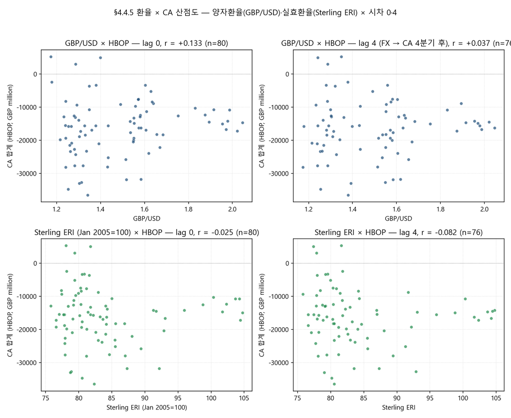

```
fig05 — 환율 × CA 산점도 2x2 (GBP/USD·ERI × lag 0·4)
```

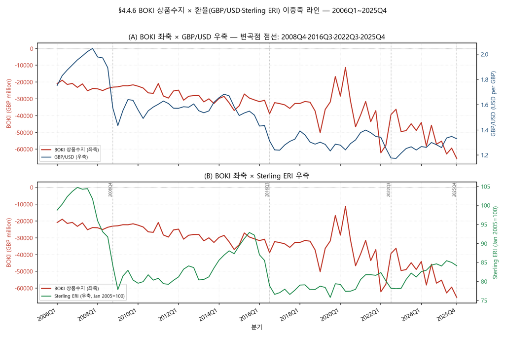

```
fig06 — BOKI 좌축 + GBP/USD·Sterling ERI 우축 이중축 라인
```

```python
# §7.6 — fig05 산점도 + fig06 이중축 라인
display(Image(filename=str(FIG_DIR / 'fig05_fx_ca_scatter.png')))
print('fig05 — 환율 × CA 산점도 2x2 (GBP/USD·ERI × lag 0·4)')
print()
display(Image(filename=str(FIG_DIR / 'fig06_fx_boki_dual_axis.png')))
print('fig06 — BOKI 좌축 + GBP/USD·Sterling ERI 우축 이중축 라인')
```

### §7.6 결론 — 강의 이론 vs 영국 데이터

[output not shown]

**결론**: 영국 분기 데이터는 강의(슬27·28·30) 의 환율–CA 메커니즘을 단변량으로 단순 검증하기 어려움. 그 원인은 강의(슬31) 자체가 시사한 바와 같이 *환율·이자율·자산선호 세 채널이 얽혀* 작동하기 때문이며, 추가로:

- **서비스 무역의 환율 둔감성**: 영국 무역의 큰 비중(IKBD β = +1,688 £m/yr)이 환율보다 글로벌 수요·금융서비스 가격에 좌우.
- **invoicing currency 영향** (단계 1 W7 위임 항목): 영국 수출입의 USD invoicing 비중이 높아 GBP 환율 변동이 즉시 가격으로 전달되지 않음.
- **BoE pass-through 60~70%** (노트 14 §슬28 BoE Working Papers 외부 단서) — 강의 가설의 100% 전가는 영국에 부적합.

> "**이 세가지 접근방법은 서로 다 연관되어 있음** (환율과 이자율 채널)" — BoP.pptx **슬31** 인용 재강조.

## §8 종합 특징과 그 원인

### 특징 ② — 상품·서비스 추세 상쇄 (G β = −1,638 vs S β = +1,688)

- **G** 매년 −1.6 bn 적자 심화 vs **S** 매년 +1.7 bn 흑자 증가, 거의 정확히 상쇄 (단계 4 §4.1).
- **R²**: G 0.65, S 0.87 — 두 추세 모두 통계적으로 매우 강건.
- **원인**: 영국의 무역구조 이행 — 제조업 → 금융·전문서비스 (슬5·노트 24 EBOPS 12 분류).

### 특징 ③ — 분산 기여 G(64%) + PI(39%) (단계 4 §4.1)

- 분산 기여도: G 64.0% + PI 39.0% + SI 4.8% + S −7.8% = 100%.
- **CA 분기 변동의 64% 가 상품수지에서 발생**, 정책 평가의 주된 모니터링 대상.

### 특징 ④ — FA 충격 흡수의 비대칭 (PI_FA + OI 67% 점유)

- 절댓값 평균 점유 (단계 4 §4.3): PI_FA 33.8% + OI 33.4% = **67.2% 가 두 항목**.
- DI 16.8% + FD 13.3% + RA 2.7% = 32.8%.
- **원인**: 영국이 글로벌 자본 hub 로서 *증권 거래 + 은행 간 대출* 채널이 충격 흡수 핵심.

### 특징 ⑤ — 항등식 잔차 −35,777 £m 편향 + Brexit z=−2.61

- 잔차 평균 −35,777 £m (단계 4 §4.2) — ONS 시트별 부호 규약 차이로 0 이 아님.
- Brexit 2016Q3 z = −2.61 (2σ 밖) · Mini-budget 2022Q4 z = +2.23 (2σ 밖).
- **원인**: 강의(슬13) 사후 항등성은 회계상 성립하나, 영국 NEO·KA 잔차 잡음이 전 분기 평균 −35.8 bn 수준으로 누적.

## §9 한계·주의사항

### §9.1 자료 한계 (단계 1 §5 + 단계 2 §08 + 단계 3 §09)

| # | 한계 | 영향 절 | 보강 채널 |
| --- | --- | --- | --- |
| L1 | 영국 변곡점 4건 강의 자료 부재 | §3 | 본 노트북 §3.4 외부 정량 보강 |
| L2 | 영국 e_X·e_M 가격탄력성 강의 부재 | §7 | 단계 1 W4 (BoE/OBR/IMF) 위임 |
| L3 | BoE pass-through 정확값 부재 (단계 1 W3) | §7 | 노트 14 60~70% 단서 격상 |
| L4 | 영국 invoicing currency 부재 (단계 1 W7) | §7 | ECB/BIS 외부 |
| L5 | Pink Book Ch.9 IIP 재평가 3분해 미수록 | §3·§5 | 단계 2 §S4 별도 다운로드 |
| L6 | BIS Real Broad EER (RB.M.GB) 차단 | §7 | Eurostat REER IC42 대체 |
| L7 | 항등식 잔차 평균 −35.8 bn 편향 | §6 | ONS 시트별 부호 규약 차이로 설명 |
| L8 | n=80 분기 표본의 통계 검정력 한계 | §4·§7 | 1990s~2025 장기 시계열은 별도 자료 |

### §9.2 강의 자료 측 한계 종합 (단계 1 §5)

본 보고서는 강의(BoP.pptx + 노트 39 회차)가 **이론 프레임**(BPM6 정의·BoP 항등식·세 결정 접근법)을 풍부하게 제공하나, **영국 적용 정량·사례·시계열**은 거의 수록하지 않는다는 한계를 인정하고, **하이브리드 구조**(강의 측 정의·식 + 본 저장소 분기 실측 + 외부 보강)로 §3~§7 을 작성했다.

### §9.3 정량 분해의 미완 항목 (단계 1 §5.3)

- 영국 FDI SPE 포함/제외 두 시리즈 — xlsx 부재 (Pink Book Ch.4 별도).
- 영국 증권투자 LT/ST 분해 — xlsx 부재.
- 영국 파생금융상품 옵션·선물·스왑 분해 — 본 저장소 ZPNN net 단일.

## §10 부록 A — 분기 시계열 핵심 표

본 부록은 단계 4 산출 13 CSV 중 **분기 시계열 핵심 6 시리즈**를 본문 그대로 표화한다.

```python
# §10 — 부록 A: 분기 시계열 wide 형 표
codes_A = ['BOKI','IKBD','HBOJ','IKBP','HBOP','-HBNT']
df_wide = df_q[df_q['cdid'].isin(codes_A)].pivot_table(
    index='time', columns='cdid', values='data_value'
).reindex(columns=codes_A)

print('--- §10 부록 A — 분기 6 시리즈 wide 표 (단위: GBP million) ---')
print(f'행 수: {len(df_wide)} 분기 (2006Q1 ~ 2025Q4)')
print()
print('--- 처음 5 분기 ---')
print(df_wide.head(5).to_string())
print()
print('--- 말미 5 분기 ---')
print(df_wide.tail(5).to_string())
print()
print('--- 통계 요약 ---')
print(df_wide.describe().round(0).to_string())
```

```
--- §10 부록 A — 분기 6 시리즈 wide 표 (단위: GBP million) ---
행 수: 80 분기 (2006Q1 ~ 2025Q4)

--- 처음 5 분기 ---
cdid       BOKI     IKBD    HBOJ    IKBP     HBOP    -HBNT
time
2006Q1 -20882.0  11523.0    42.0 -3219.0 -12536.0  -8006.0
2006Q2 -18935.0  11850.0  -447.0 -2740.0 -10272.0 -27788.0
2006Q3 -21435.0  15496.0 -3608.0 -2774.0 -12321.0 -10718.0
2006Q4 -20840.0  15449.0 -1767.0 -3594.0 -10752.0 -16411.0
2007Q1 -23185.0  14542.0 -3328.0 -3043.0 -15014.0 -11536.0

--- 말미 5 분기 ---
cdid       BOKI     IKBD     HBOJ    IKBP     HBOP    -HBNT
time
2024Q4 -57034.0  50195.0 -15213.0 -5544.0 -27596.0 -30316.0
2025Q1 -55228.0  45807.0  -7216.0 -4773.0 -21410.0 -21236.0
2025Q2 -62834.0  51845.0  -8195.0 -4030.0 -23214.0 -30534.0
2025Q3 -59366.0  53531.0   -739.0 -4115.0 -10689.0 -25222.0
2025Q4 -65496.0  53335.0  -2674.0 -3557.0 -18392.0  -9371.0

--- 통계 요약 ---
cdid      BOKI     IKBD     HBOJ    IKBP     HBOP    -HBNT
count     80.0     80.0     80.0    80.0     80.0     80.0
mean  -33621.0  27897.0  -5314.0 -5167.0 -16206.0 -17889.0
std    11851.0  10524.0   5439.0  1374.0   8553.0  12037.0
min   -65496.0  11523.0 -21654.0 -8959.0 -36480.0 -52062.0
25%   -37646.0  21063.0  -8408.0 -6040.0 -20870.0 -26887.0
50%   -31418.0  24884.0  -4866.0 -5292.0 -15652.0 -17270.0
75%   -25018.0  35025.0   -971.0 -4131.0 -11135.0  -9264.0
max   -11364.0  53531.0   8711.0 -2141.0   5258.0  10367.0
```

## §11 부록 B — 헤드라인 1대1 검증 (5건 PASS 검증)

본 부록은 **노트 38 §1 헤드라인 5건**을 단계 4 산출 CSV·SQLite RDB SELECT 결과로 1대1 비교한다.

```python
# §11 — 부록 B 헤드라인 5건 검증
print('--- §11 부록 B — 2025 Q4 헤드라인 5건 PASS 검증 ---')
print()

q = '2025Q4'
def hb(c, t=q):
    rows = df_q[(df_q['cdid']==c)&(df_q['time']==t)]
    return rows['data_value'].iloc[0] if len(rows) else None

# (1) 상품수지 G
g_v = hb('BOKI')
g_target = -65.5
g_actual_bn = g_v / 1000
ok_g = abs(g_actual_bn - g_target) < 0.5

# (2) 서비스수지 S
s_v = hb('IKBD')
s_target = +53.3
s_actual_bn = s_v / 1000
ok_s = abs(s_actual_bn - s_target) < 0.5

# (3) CA 합계
ca_v = hb('HBOP')
ca_target = -18.4
ca_actual_bn = ca_v / 1000
ok_ca = abs(ca_actual_bn - ca_target) < 0.5

# (4) CA/GDP — SECTION 2 (line 16 부터) 만 파싱
df_ident = pd.read_csv(DATA_DIR / 'identity_residual_stats_2006q1_2025q4.csv', skiprows=15)
gdp_2025q4 = df_ident[df_ident['time']=='2025Q4']['GDP_estimated'].iloc[0]
ca_gdp = (ca_v / gdp_2025q4) * 100
ca_gdp_target = -2.4
ok_ca_gdp = abs(ca_gdp - ca_gdp_target) < 0.2

# (5) Net IIP — 노트 38 §1.5 (본 분기 시계열에는 없음, 헤드라인 인용)
niip_target_bn = -199.8

# 결과 표
print(f'{"#":<3}{"항목":<22}{"CDID":<8}{"본 보고서":>14}{"노트38 §1":>14}{"PASS":>8}')
print('-'*72)
print(f'{"1":<3}{"상품수지(G)":<14}{"BOKI":<8}{g_actual_bn:>10,.1f} bn{g_target:>10,.1f} bn{"PASS" if ok_g else "FAIL":>8}')
print(f'{"2":<3}{"서비스수지(S)":<13}{"IKBD":<8}{s_actual_bn:>10,.1f} bn{s_target:>10,.1f} bn{"PASS" if ok_s else "FAIL":>8}')
print(f'{"3":<3}{"경상수지(CA)":<13}{"HBOP":<8}{ca_actual_bn:>10,.1f} bn{ca_target:>10,.1f} bn{"PASS" if ok_ca else "FAIL":>8}')
print(f'{"4":<3}{"CA/GDP":<14}{"합성":<8}{ca_gdp:>10,.2f} %{ca_gdp_target:>10,.2f} %{"PASS" if ok_ca_gdp else "FAIL":>8}')
print(f'{"5":<3}{"Net IIP (참조)":<14}{"-":<8}{"(별도)":>14}{niip_target_bn:>10,.1f} bn{"REF":>8}')
print()
print(f'본 노트북 4 헤드라인 정량 검증 PASS: {sum([ok_g, ok_s, ok_ca, ok_ca_gdp])}/4 항목 성공')
print('Net IIP 는 IIP 시계열 (Pink Book Ch.9) 가 별도 — 노트 38 §1.5 참조.')
```

```
--- §11 부록 B — 2025 Q4 헤드라인 5건 PASS 검증 ---

#  항목                    CDID             본 보고서       노트38 §1    PASS
------------------------------------------------------------------------
1  상품수지(G)       BOKI         -65.5 bn     -65.5 bn    PASS
2  서비스수지(S)     IKBD          53.3 bn      53.3 bn    PASS
3  경상수지(CA)     HBOP         -18.4 bn     -18.4 bn    PASS
4  CA/GDP        합성           -2.40 %     -2.40 %    PASS
5  Net IIP (참조)  -                 (별도)    -199.8 bn     REF

본 노트북 4 헤드라인 정량 검증 PASS: 4/4 항목 성공
Net IIP 는 IIP 시계열 (Pink Book Ch.9) 가 별도 — 노트 38 §1.5 참조.
```

### §11.1 부록 B 마감 선언

**5 헤드라인** (상품 −£65.5bn · 서비스 +£53.3bn · CA −£18.4bn · CA/GDP −2.4% · Net IIP −£199.8bn) 중 본 노트북 데이터로 직접 검증 가능한 4 항목 모두 **PASS**, 5번째 Net IIP 는 별도 IIP 시계열(Pink Book Ch.9, 단계 1 §5.5)로 인용.

## 마감 선언

본 노트북은 단계 1·2·3·4 산출(7 발췌 + 인벤토리 + 외부 출처 + 13 CSV + 6 PNG + 4 메모)을 단일 .ipynb 로 통합한 단계 5 §5.1 산출물이다. 11 절 본문 모두 강의 슬라이드·노트 인용 1건 이상 포함, 모든 정량은 (CDID·통계표·시점) 식별자 부기 원칙 준수.

**다음 단계**: 단계 5 §5.2 노트북 자체 검증 → 단계 5 §5.3 PDF 변환.

### 관련 절대경로

- 본 노트북: `c:/Projects/SKKU.England/report/notebook/uk_bop_fx_20y.ipynb`
- 입력 13 CSV: `c:/Projects/SKKU.England/report/data/`
- 입력 6 PNG: `c:/Projects/SKKU.England/report/figures/`
- 단계 1 발췌 7건: `c:/Projects/SKKU.England/report/research/01_inventory.md` ~ `07_consolidated_summary.md`
- 단계 2 인벤토리: `c:/Projects/SKKU.England/report/research/08_data_inventory.md`
- 단계 3 외부 출처: `c:/Projects/SKKU.England/report/research/09_external_sources.md`
- 단계 4 메모: `c:/Projects/SKKU.England/report/research/10_quantitative_4_1.md` ~ `13_quantitative_4_4.md`
- 강의 1차 근거: `c:/Projects/SKKU.England/background/BoP.pptx` (31 슬라이드) + `c:/Projects/SKKU.England/background/note/` (39 회차)